# Base Plotting in **R**: More Tricks

[EFB 654: R and Reproducible Research](https://eligurarie.github.io/EFB654/)

Elie Gurarie

February 18, 2026

## Goal: plotting many dimensions at once

A single scatter plot can convey more than just two variables. By mapping additional data onto visual properties — point size, color, transparency, and text labels — we can pack many dimensions of information into one figure without making it unreadable. This lab walks through building such a plot step by step, using country-level data from the World Bank.

The data are here: WDI.csv

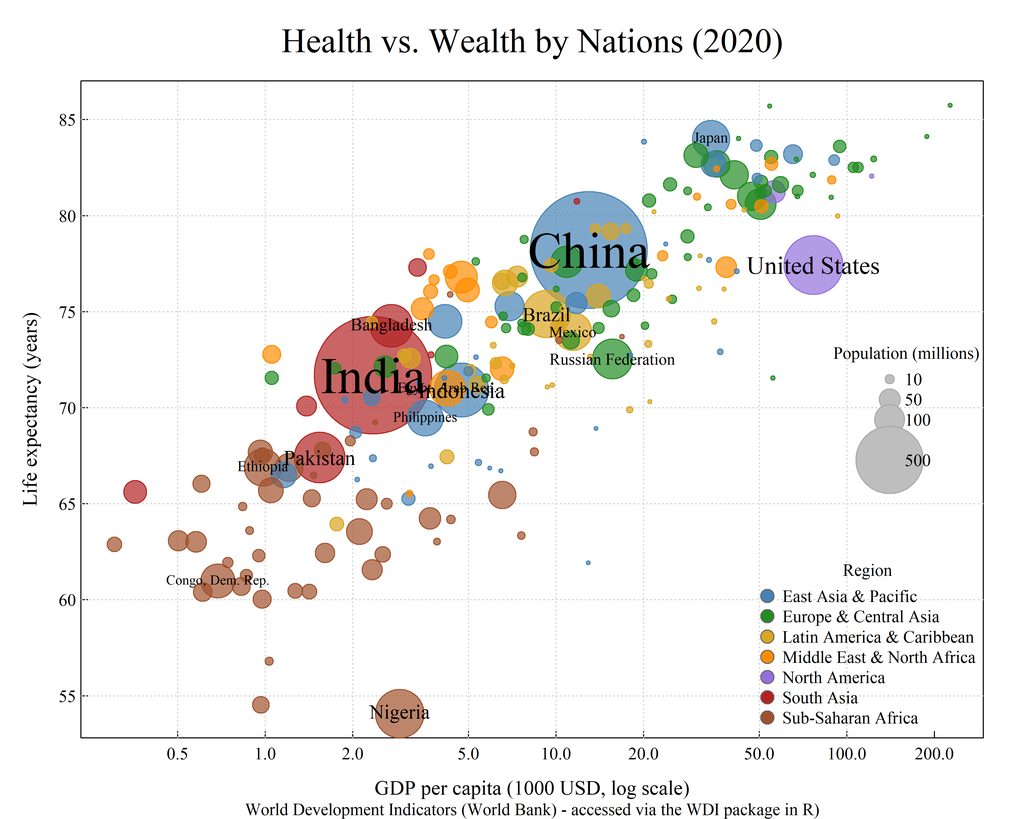

## The data

We use the `WDI.csv` file, downloaded from the World Bank’s World Development Indicators via the `WDI` package. It contains one row per country with variables including life expectancy, GDP per capita, population, land area, geographic coordinates, and World Bank region. Load it and inspect its structure before plotting.

```r
wdi <- read.csv("WDI.csv")
str(wdi)
```

```
## 'data.frame':    208 obs. of  16 variables:
##  $ country    : chr  "India" "China" "United States" "Indonesia" ...
##  $ iso2c      : chr  "IN" "CN" "US" "ID" ...
##  $ iso3c      : chr  "IND" "CHN" "USA" "IDN" ...
##  $ year       : int  2022 2022 2022 2022 2022 2022 2022 2022 2022 2022 ...
##  $ status     : logi  NA NA NA NA NA NA ...
##  $ lastupdated: chr  "2026-01-28" "2026-01-28" "2026-01-28" "2026-01-28" ...
##  $ LifeExp    : num  71.7 78.2 77.4 70.9 67.4 ...
##  $ GDP        : num  2347 12971 76657 4731 1538 ...
##  $ Area       : num  2973190 9388210 9147420 1892555 770880 ...
##  $ Population : int  1425423212 1412175000 334017321 278830529 243700667 223150896 210306415 169384897 144236933 128613117 ...
##  $ region     : chr  "South Asia" "East Asia & Pacific" "North America" "East Asia & Pacific" ...
##  $ capital    : chr  "New Delhi" "Beijing" "Washington D.C." "Jakarta" ...
##  $ longitude  : num  77.2 116.3 -77 106.8 72.8 ...
##  $ latitude   : num  28.6 40 38.9 -6.2 30.5 ...
##  $ income     : chr  "Lower middle income" "Upper middle income" "High income" "Upper middle income" ...
##  $ lending    : chr  "IBRD" "IBRD" "Not classified" "IBRD" ...
```

## Step 1 — a plain scatter plot

Start with the simplest possible plot: GDP per capita (divided by 1000 for readability) on the x-axis and life expectancy on the y-axis. This gives us the baseline to build from.

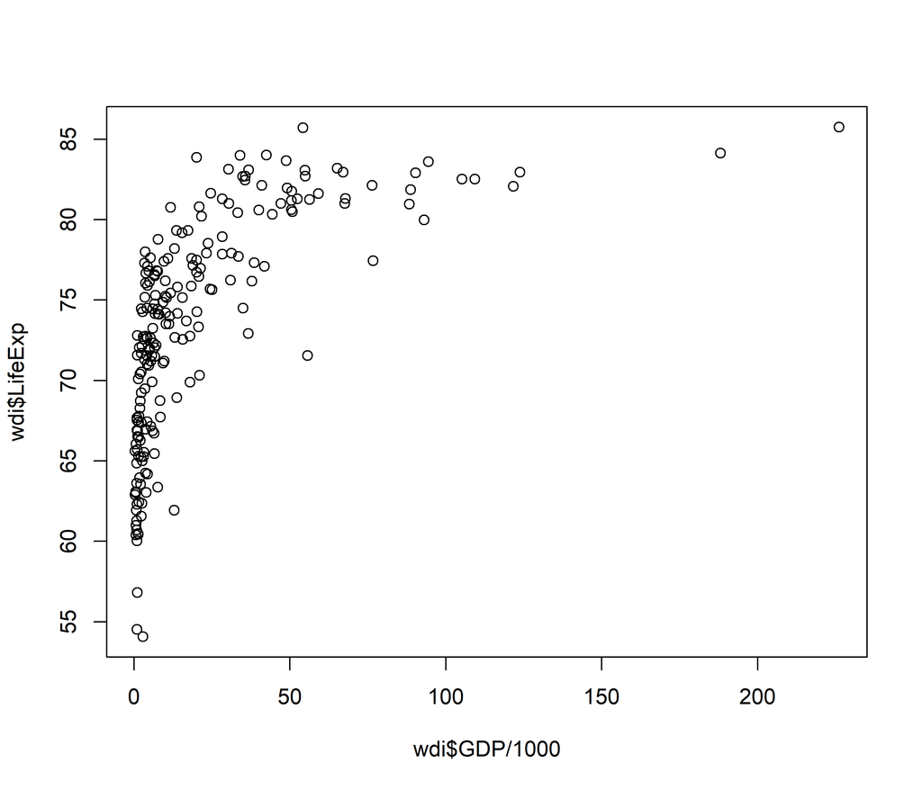

```r
plot(wdi$GDP/1e3, wdi$LifeExp)
```

Very basic.

- How to deal with clustering?

## Step 1b — log scale on x

GDP per capita is highly right-skewed — a handful of wealthy countries pull the scale so far that most of the variation among poorer countries is compressed into a narrow strip. A log x-axis spreads the data out and reveals the relationship much more clearly. While we’re at it, we polish the axes with `par()`.

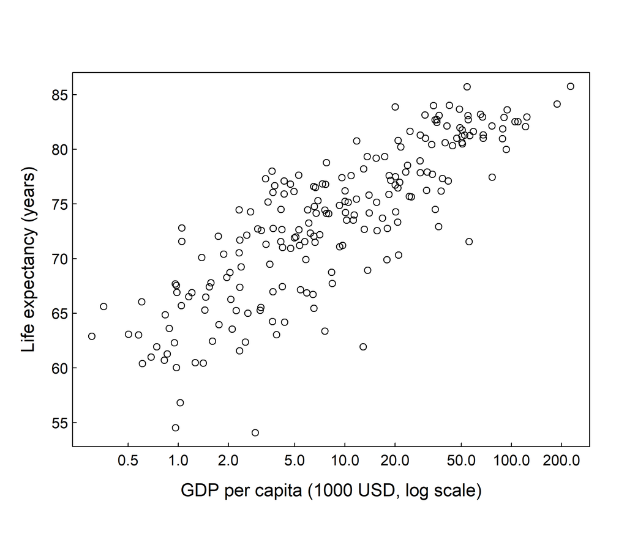

```r
par(cex.lab = 1.2, las = 1,
    mgp = c(2, .25, 0), tck = 0.01)

plot(wdi$GDP/1e3, wdi$LifeExp,
     log  = "x",
     xlab = "GDP per capita (1000 USD, log scale)",
     ylab = "Life expectancy (years)")
```

`log = "x"` applies a log axis  
(`log = "y"`, `log = "xy"` also work)

`las = 1` — horizontal tick labels  
`tck = 0.01` — inward ticks  
`mgp` — controls axis label / tick label / tick line positions

## `par()` reference

`par()` is R’s global graphics parameter function — it controls everything from margins to font family to tick direction. Changes made with `par()` persist for the rest of the plot (or until reset), so it’s usually called once at the top of a plotting block. Here are the parameters most relevant today.

`bty` controls the **b**ox **ty**pe around the plot:

| value | box drawn |
| --- | --- |
| `"o"` | full box (default) |
| `"l"` | bottom + left only |
| `"u"` | bottom + sides |
| `"c"` | top + sides |
| `"n"` | no box |

Other useful `par()` tweaks for today:

| parameter | what it does |
| --- | --- |
| `cex.lab` | axis label size |
| `cex.axis` | tick label size |
| `mar` | margins (bottom, left, top, right) |
| `mgp` | axis title, tick label, tick line positions |
| `las` | tick label orientation |
| `tck` | tick length (+inward, −outward) |
| `family` | font family (`"serif"`, `"sans"`, `"mono"`) |

```r
par("mar")   # default margins
```

```
## [1] 5.1 4.1 4.1 2.1
```

```r
par("mgp")   # default mgp
```

```
## [1] 3 1 0
```

## Step 2 — size points by population

A third quantitative variable — population — can be encoded as point size using the `cex` argument. We scale each country’s circle so that its **area** is proportional to population.

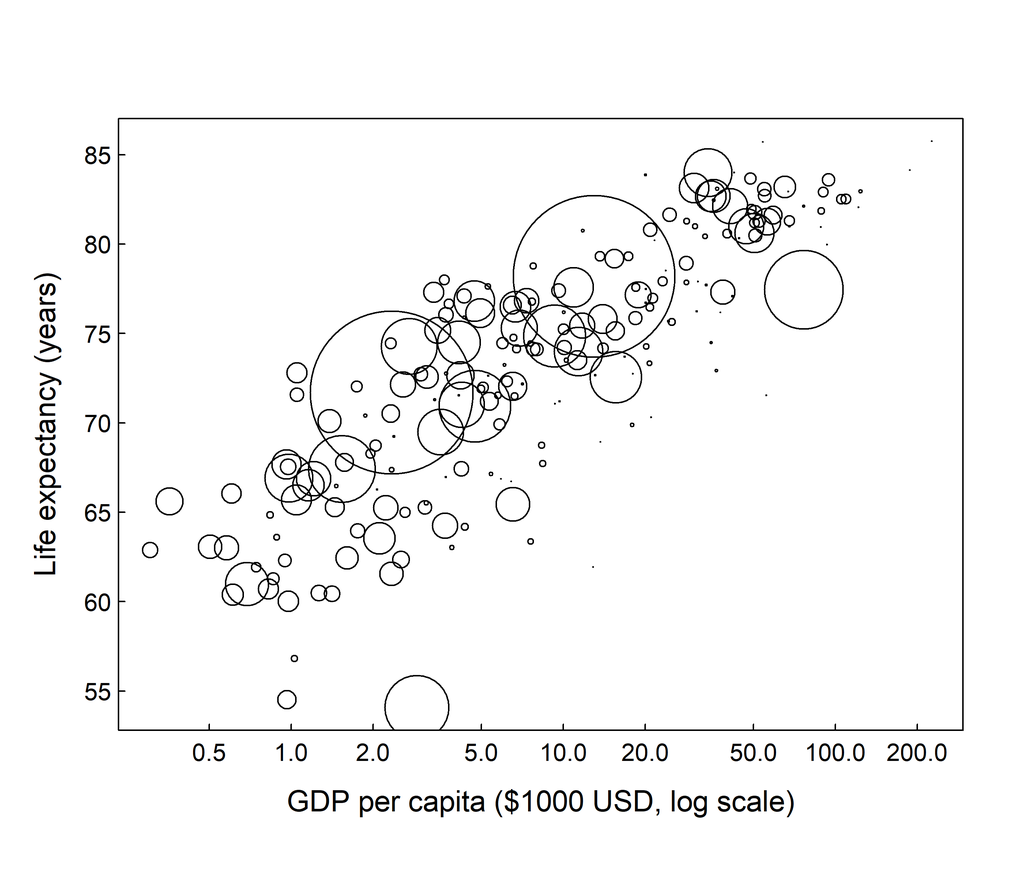

```r
par(cex.lab = 1.2, las = 1,
    mgp = c(2, .25, 0), tck = 0.01)

plot(wdi$GDP/1e3, wdi$LifeExp,
     log  = "x",
     xlab = "GDP per capita ($1000 USD, log scale)",
     ylab = "Life expectancy (years)",
     cex  = sqrt(wdi$Population /
                 max(wdi$Population,
                     na.rm = TRUE)) * 15)
```

`cex` controls point size  
`sqrt()` makes **area** proportional to population

## Why `sqrt()`?

A circle’s **area** = π r²

If we set `cex` proportional to population directly, the *radius* scales linearly — but our eye reads **area**.

To make area proportional to population:

$$r \propto
\sqrt{\text{population}}$$

So we use:

```r
cex = sqrt(Population / max_pop) * 15
```

The `* 15` just scales up to a visible range.

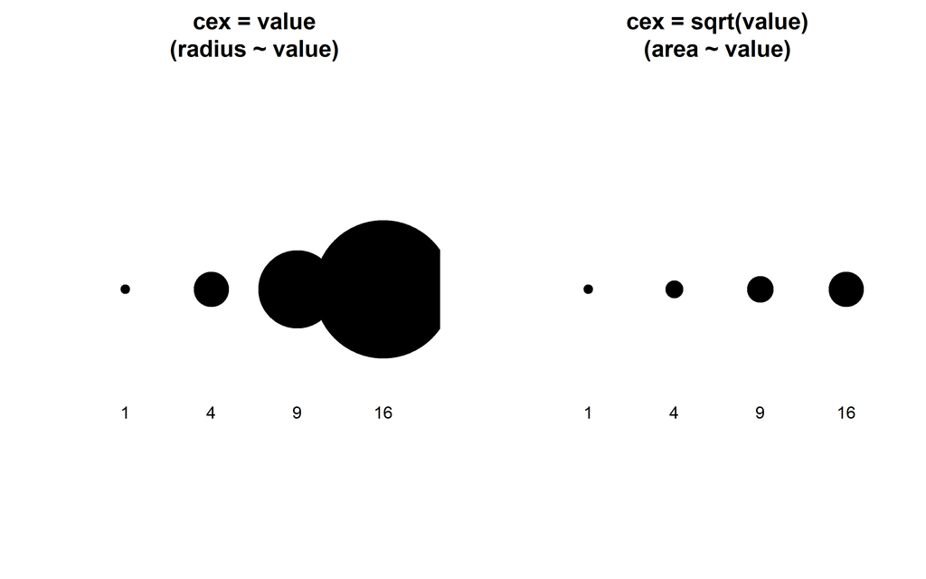

## Step 2b — add transparency

With variable-size points, overlap becomes a problem — large circles hide smaller ones beneath them. Transparency helps: points that overlap produce a visually darker region, preserving information about density. Use `pch = 21` (filled circle) so border and fill can be controlled independently, and set the fill with `rgb()` including an alpha value.

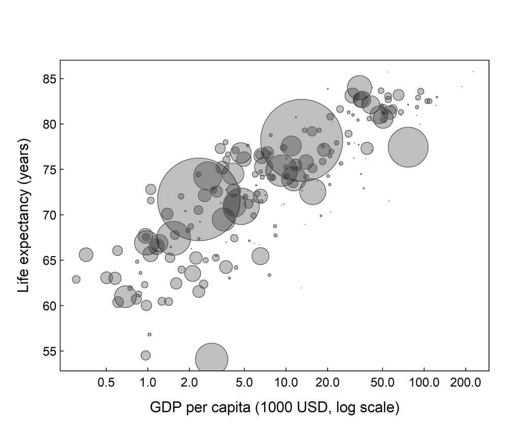

```r
par(cex.lab = 1.2, las = 1,
    mgp = c(2, .25, 0), tck = 0.01)

plot(wdi$GDP/1e3, wdi$LifeExp,
     log  = "x",
     xlab = "GDP per capita (1000 USD, log scale)",
     ylab = "Life expectancy (years)",
     cex  = sqrt(wdi$Population /
                 max(wdi$Population,
                     na.rm = TRUE)) * 15,
     pch  = 21,
     col  = "grey40",
     bg   = rgb(0, 0, 0, 0.25))
```

`pch = 21` — filled circles with separate border/fill  
`rgb(r, g, b, alpha)` — alpha: 0 = transparent, 1 = opaque

Transparency reveals overlapping points.

## `rgb()` and color in R

`rgb()` creates colors by specifying red, green, and blue channels (0–1 scale), plus an optional alpha (transparency) channel. The `adjustcolor()` base R function and `scales::alpha()` offer convenient shortcuts for adding transparency to named colors.

```r
# Pure red, 50% transparent
rgb(1, 0, 0, 0.5)

# Any named color with alpha:
adjustcolor("steelblue", alpha.f = 0.4)

# scales package convenience function:
scales::alpha("steelblue", 0.4)
```

```r
rgb(1, 0, 0, 0.5)
```

```
## [1] "#FF000080"
```

```r
adjustcolor("steelblue", alpha.f = 0.4)
```

```
## [1] "#4682B466"
```

All values 0–1 (or use `maxColorValue = 255`)

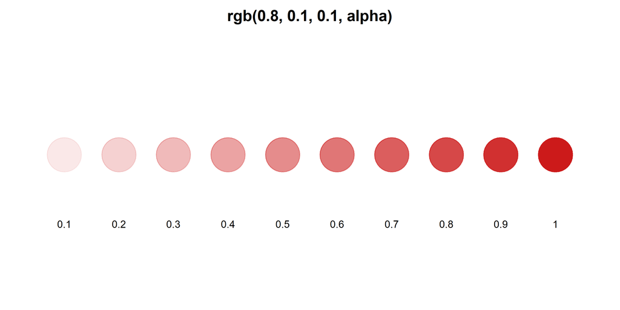

## Step 3 — color by region

Now we encode a fourth variable — World Bank region — as point color. We define a named color vector `cols` where each name is a region label, then use `match()` to look up the right color for every row in the data frame.

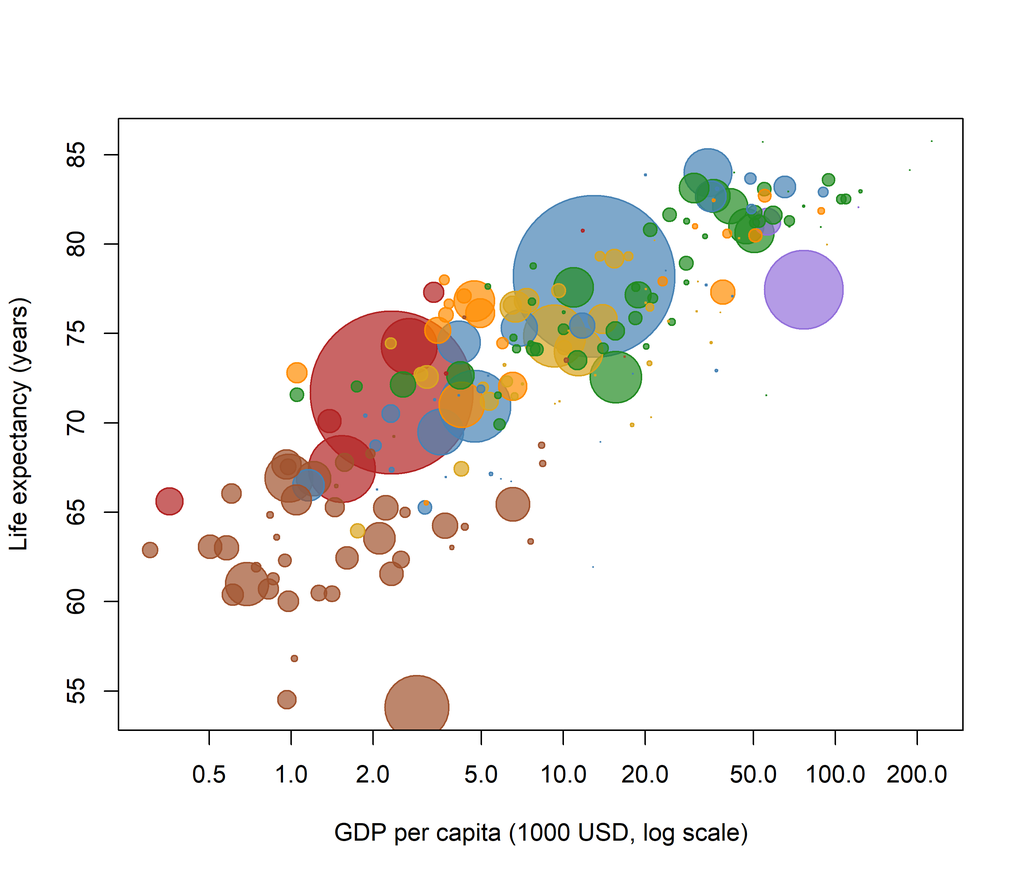

```r
wdi$region <- factor(wdi$region)

cols <- c(
  "East Asia & Pacific"        = "steelblue",
  "Europe & Central Asia"      = "forestgreen",
  "Latin America & Caribbean"  = "goldenrod",
  "Middle East & North Africa" = "darkorange",
  "North America"              = "mediumpurple",
  "South Asia"                 = "firebrick",
  "Sub-Saharan Africa"         = "sienna")

cont_col <- cols[match(wdi$region,
                       levels(wdi$region))]

plot(wdi$GDP/1e3, wdi$LifeExp, log = "x",
     xlab = "GDP per capita (1000 USD, log scale)",
     ylab = "Life expectancy (years)",
     cex  = sqrt(wdi$Population /
                 max(wdi$Population, na.rm=TRUE))*15,
     pch = 21, col = cont_col,
     bg  = scales::alpha(cont_col, .7))
```

## How `match()` maps colors to categories

The trick is straightforward: `factor()` stores categories as integers (1, 2, 3, …) mapped to an ordered list of `levels()`. `match()` retrieves that integer for each observation, which we use as an index into our color vector. This pattern works for any named vector — colors, point characters, line types — not just `cols`.

`levels()` gives factor levels in order

```r
levels(wdi$region)
```

```
## [1] "East Asia & Pacific"        "Europe & Central Asia"
## [3] "Latin America & Caribbean"  "Middle East & North Africa"
## [5] "North America"              "South Asia"
## [7] "Sub-Saharan Africa"
```

`match()` returns each row’s position in that ordered list

```r
wdi$region[1:20]
```

```
##  [1] South Asia                 East Asia & Pacific
##  [3] North America              East Asia & Pacific
##  [5] South Asia                 Sub-Saharan Africa
##  [7] Latin America & Caribbean  South Asia
##  [9] Europe & Central Asia      Latin America & Caribbean
## [11] Sub-Saharan Africa         East Asia & Pacific
## [13] East Asia & Pacific        Middle East & North Africa
## [15] Sub-Saharan Africa         East Asia & Pacific
## [17] Middle East & North Africa Europe & Central Asia
## [19] Europe & Central Asia      East Asia & Pacific
## 7 Levels: East Asia & Pacific ... Sub-Saharan Africa
```

```r
match(wdi$region, levels(wdi$region))[1:20]
```

```
##  [1] 6 1 5 1 6 7 3 6 2 3 7 1 1 4 7 1 4 2 2 1
```

`cols[match(...)]` picks the right color by index

```r
cols[match(wdi$region, levels(wdi$region))][1:20]
```

```
##                 South Asia        East Asia & Pacific
##                "firebrick"                "steelblue"
##              North America        East Asia & Pacific
##             "mediumpurple"                "steelblue"
##                 South Asia         Sub-Saharan Africa
##                "firebrick"                   "sienna"
##  Latin America & Caribbean                 South Asia
##                "goldenrod"                "firebrick"
##      Europe & Central Asia  Latin America & Caribbean
##              "forestgreen"                "goldenrod"
##         Sub-Saharan Africa        East Asia & Pacific
##                   "sienna"                "steelblue"
##        East Asia & Pacific Middle East & North Africa
##                "steelblue"               "darkorange"
##         Sub-Saharan Africa        East Asia & Pacific
##                   "sienna"                "steelblue"
## Middle East & North Africa      Europe & Central Asia
##               "darkorange"              "forestgreen"
##      Europe & Central Asia        East Asia & Pacific
##              "forestgreen"                "steelblue"
```

## Step 4 — add a legend

A color-coded plot is incomplete without a legend. The `legend()` function is flexible but has many arguments — the key ones for categorical point data are shown below.

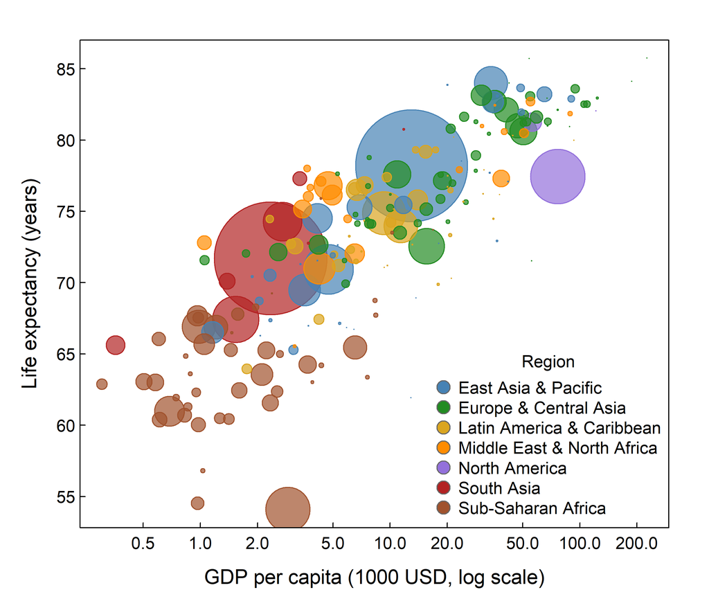

```r
par(cex.lab = 1.2, las = 1,
    mar = c(4, 4, 2, 2),
    mgp = c(2, .25, 0), tck = 0.01)
plot(wdi$GDP/1e3, wdi$LifeExp, log = "x",
     xlab = "GDP per capita (1000 USD, log scale)",
     ylab = "Life expectancy (years)",
     cex = sqrt(wdi$Population /
                max(wdi$Population, na.rm=TRUE))*15,
     pch = 21, col = cont_col,
     bg  = scales::alpha(cont_col, .7))

legend("bottomright", title = "Region",
       legend = levels(wdi$region),
       pt.bg  = cols,
       col    = "grey40",
       pch    = 21,
       pt.cex = 1.8,
       bty    = "n")
```

## `legend()` key arguments

```r
legend(
  x      = "bottomright", # position or coordinates
  legend = ...,           # text labels
  col    = ...,           # point/line colors
  pch    = ...,           # point character
  lty    = ...,           # line types (if lines)
  pt.cex = 2,             # symbol size in legend
  cex    = 0.9,           # text size
  bty    = "n",           # no box around legend
  title  = "Region"       # optional title
)
```

Position keywords:  
`"topleft"`, `"topright"`, `"bottomleft"`, `"bottomright"`, `"top"`, `"right"`, …

Or give exact coordinates: `legend(x = 0.5, y = 60, ...)`

For **filled** circles (`pch = 21`), use both `col` (border) and `pt.bg` (fill):

```r
legend("bottomright",
       legend = levels(wdi$region),
       pt.bg  = cols,      # fill
       col    = "grey40",  # border
       pch    = 21,
       pt.cex = 1.8,
       bty    = "n")
```

`pch 21–25` are **filled** shapes — border color (`col`) and fill (`bg` or `pt.bg`) are independent.

## Step 5 — reorder by population

R draws points in row order, so later rows are drawn on top of earlier ones. If we plot small countries last, they appear on top of and remain visible beneath the large-population circles. Sorting by decreasing population before plotting solves the occlusion problem.

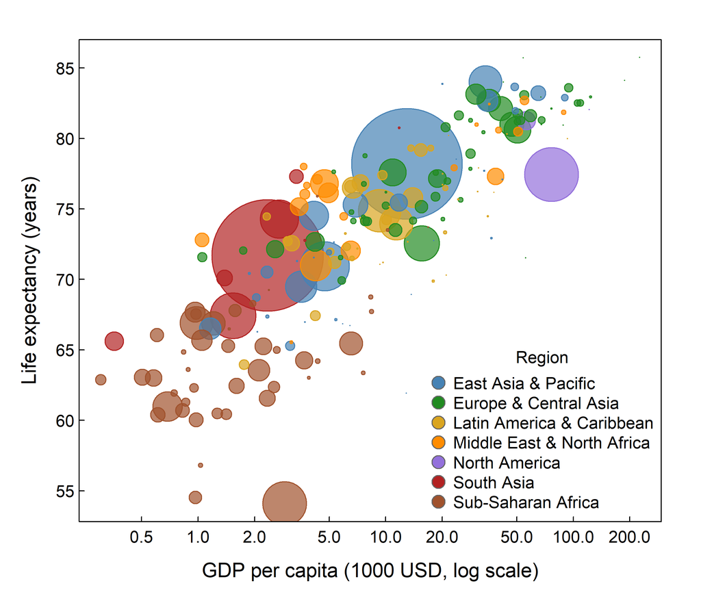

```r
# Sort descending so large (populous) countries
# are drawn first — smaller ones on top
wdi <- wdi[order(wdi$Population,
                 decreasing = TRUE), ]

cont_col <- cols[match(wdi$region,
                       levels(wdi$region))]
cex_pop  <- sqrt(wdi$Population /
                 max(wdi$Population,
                     na.rm = TRUE)) * 15

par(cex.lab = 1.2, las = 1,
    mar = c(4, 4, 2, 2),
    mgp = c(2, .25, 0), tck = 0.01)
plot(wdi$GDP/1e3, wdi$LifeExp, log = "x",
     xlab = "GDP per capita (1000 USD, log scale)",
     ylab = "Life expectancy (years)",
     cex = cex_pop, pch = 21,
     col = cont_col,
     bg  = scales::alpha(cont_col, .7))
legend("bottomright", title = "Region",
       legend = levels(wdi$region),
       pt.bg = cols, col = "grey40",
       pch = 21, pt.cex = 1.8, bty = "n")
```

Large countries drawn first → small countries on top and visible.

## Step 6 — label large countries

For the most populous countries, it’s worth printing the country name directly on the plot. We use `subset()` to filter to countries above a population threshold, then `text()` to draw labels at their coordinates. Scaling label size with `cex_pop` keeps large-country labels proportionally bigger.

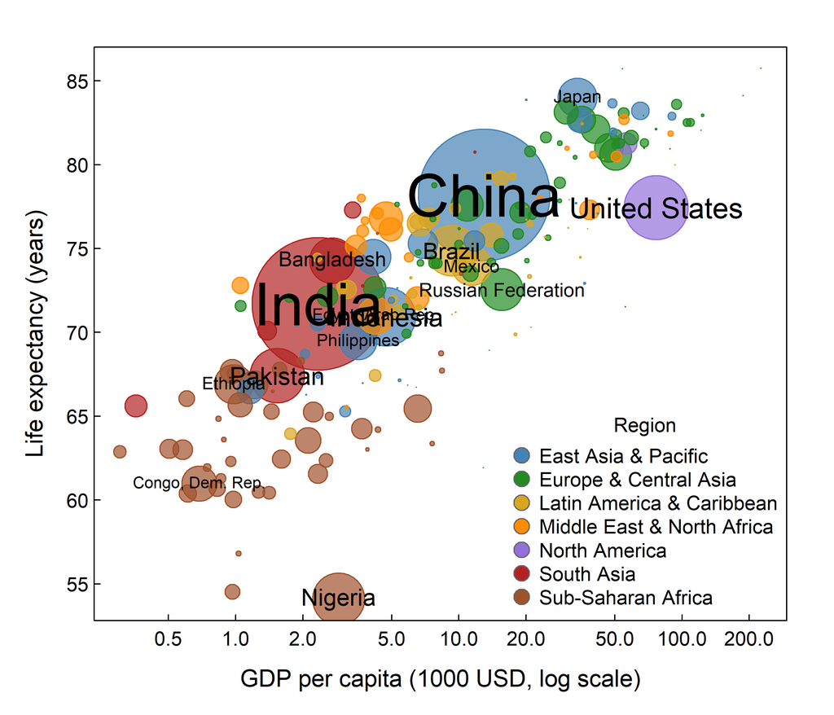

```r
par(cex.lab = 1.2, las = 1,
    mar = c(4, 4, 2, 2),
    mgp = c(2, .25, 0), tck = 0.01)
plot(wdi$GDP/1e3, wdi$LifeExp, log = "x",
     xlab = "GDP per capita (1000 USD, log scale)",
     ylab = "Life expectancy (years)",
     cex = cex_pop, pch = 21,
     col = cont_col,
     bg  = scales::alpha(cont_col, .7))
legend("bottomright", title = "Region",
       legend = levels(wdi$region),
       pt.bg = cols, col = "grey40",
       pch = 21, pt.cex = 1.8, bty = "n")

wdi_big <- subset(wdi, Population > 1e8)

text(labels = wdi_big$country,
     x      = wdi_big$GDP/1e3,
     y      = wdi_big$LifeExp,
     cex    = cex_pop[wdi$Population > 1e8] / 5,
     adj    = 0.5)
```

`adj = 0.5` — centered on the point  
(`adj`: 0=left-justified, 1=right-justified)  
`font = 2` — **bold**  
`font = 3` — *italic*  
`pos = 4` — offset to the right of coordinates

## Step 7 — custom grid lines with `abline()`

Reference grid lines help readers read off values. The key technique here is `type = "n"` — this draws the axes and sets up the plot region without plotting any points, letting us layer the grid *first* so points appear on top of it. We then use `abline()` to draw lines at specific values rather than `grid()`, which gives us full control over placement on a log axis.

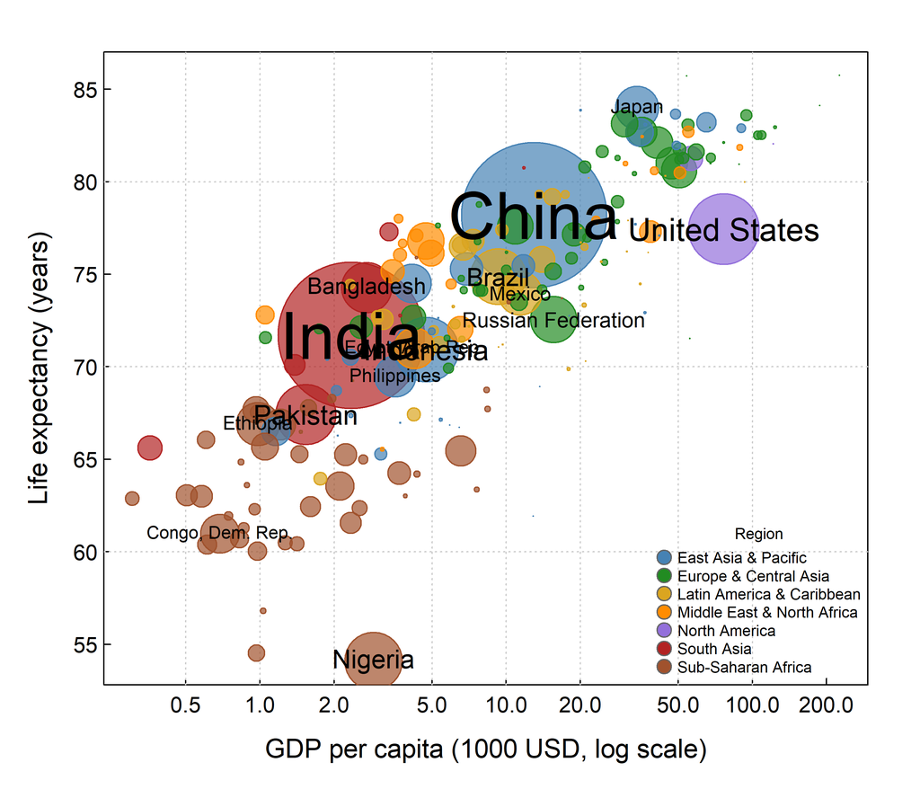

```r
par(cex.lab = 1.2, las = 1,
    mar = c(4, 4, 2, 2),
    mgp = c(2, .25, 0), tck = 0.01)
plot(wdi$GDP/1e3, wdi$LifeExp, log = "x",
     xlab = "GDP per capita (1000 USD, log scale)",
     ylab = "Life expectancy (years)",
     type = "n")
abline(h = seq(40, 90, 10), col = "grey80", lty = 3)
abline(v = c(.5,1,2,5,10,20,50,100), col = "grey80", lty = 3)
points(wdi$GDP/1e3, wdi$LifeExp,
       cex = cex_pop, pch = 21,
       col = cont_col, bg = scales::alpha(cont_col, .7))
legend("bottomright", title = "Region",
       legend = levels(wdi$region),
       pt.bg = cols, col = "grey40",
       pch = 21, pt.cex = 1.5, bty = "n", cex = 0.7)
wdi_big <- subset(wdi, Population > 1e8)
text(labels = wdi_big$country,
     x = wdi_big$GDP/1e3, y = wdi_big$LifeExp,
     cex = cex_pop[wdi$Population > 1e8]/5, adj = 0.5)
```

`abline(h = ...)` — horizontal lines at given y values  
`abline(v = ...)` — vertical lines at given x values

Preferred over `grid()` here because the x-axis is log-scale — `grid()` spaces lines at tick positions, `abline()` lets you choose exact values.

## Step 8 — a second legend for point size

The region legend explains colors, but readers still need a reference for what the circle sizes mean. A second `legend()` call encodes population by using the exact same `pt.cex` formula as the plot, applied to a set of round reference values. This ensures perfect visual consistency between the legend symbols and the data points.

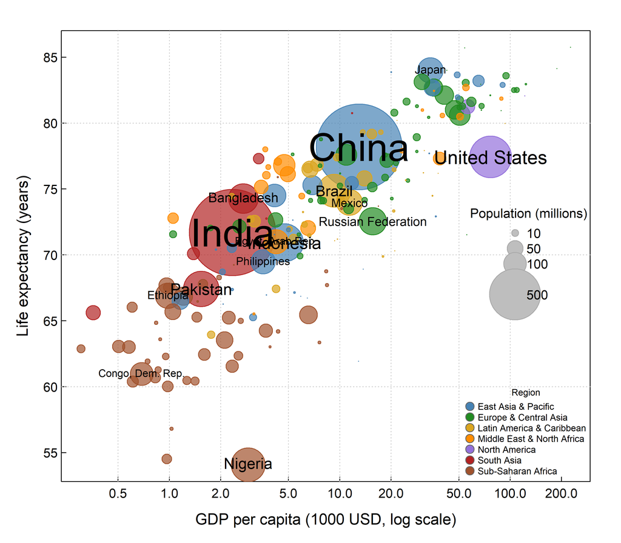

```r
par(cex.lab = 1.2, las = 1,
    mar = c(4, 4, 2, 2),
    mgp = c(2, .25, 0), tck = 0.01)
plot(wdi$GDP/1e3, wdi$LifeExp, log = "x",
     xlab = "GDP per capita (1000 USD, log scale)",
     ylab = "Life expectancy (years)", type = "n")
abline(h = seq(40, 90, 10), col = "grey80", lty = 3)
abline(v = c(.5,1,2,5,10,20,50,100), col = "grey80", lty = 3)
points(wdi$GDP/1e3, wdi$LifeExp,
       cex = cex_pop, pch = 21,
       col = cont_col, bg = scales::alpha(cont_col, .7))
legend("bottomright", title = "Region",
       legend = levels(wdi$region),
       pt.bg = cols, col = "grey40",
       pch = 21, pt.cex = 1.5, bty = "n", cex = 0.7)
legend("right", title = "Population (millions)",
       legend = c(10, 50, 100, NA, 500),
       pt.cex = sqrt(c(10, 50, 100, NA, 500)*1e6 / max(wdi$Population, na.rm = TRUE))*15,
       col = "darkgrey", pch = 21, pt.bg = "grey", bty = "n", ncol = 1)
wdi_big <- subset(wdi, Population > 1e8)
text(labels = wdi_big$country,
     x = wdi_big$GDP/1e3, y = wdi_big$LifeExp,
     cex = cex_pop[wdi$Population > 1e8]/5, adj = 0.5)
```

Key trick: `pt.cex` uses the **same formula** as the plot, applied to round reference population values.

`NA` entries create blank rows — useful for spacing.

## The full code

Here is everything assembled into a single self-contained block — from loading the data to the finished plot. This is the version to save, adapt, and build on.

```r
wdi <- read.csv("WDI.csv")
wdi <- wdi[order(wdi$Population, decreasing = TRUE), ]
wdi$region <- factor(wdi$region)

cols <- c("East Asia & Pacific"        = "steelblue",
          "Europe & Central Asia"      = "forestgreen",
          "Latin America & Caribbean"  = "goldenrod",
          "Middle East & North Africa" = "darkorange",
          "North America"              = "mediumpurple",
          "South Asia"                 = "firebrick",
          "Sub-Saharan Africa"         = "sienna")

cont_col <- cols[match(wdi$region, levels(wdi$region))]
cex_pop  <- sqrt(wdi$Population / max(wdi$Population, na.rm = TRUE)) * 15

par(cex.lab = 1.2, mar = c(4, 4, 4, 2),
    mgp = c(2, .25, 0), tck = 0.01,
    family = "serif", las = 1)

plot(wdi$GDP/1e3, wdi$LifeExp, log = "x",
     ylab = "Life expectancy (years)",
     xlab = "GDP per capita (1000 USD, log scale)", type = "n")
title("Health vs. Wealth by Nations (2020)", cex.main = 2, font.main = 1)
title(sub = "World Development Indicators (World Bank) - accessed via the WDI package in R)")
abline(h = seq(40, 90, 5), col = "grey80", lty = 3)
abline(v = c(.5,1,2,5,10,20,50,100), col = "grey80", lty = 3)
points(wdi$GDP/1e3, wdi$LifeExp,
       cex = cex_pop + .5, pch = 21, col = cont_col,
       bg  = scales::alpha(cont_col, .7))
legend("bottomright", title = "Region",
       legend = levels(wdi$region),
       pt.bg = cols, col = "grey40",
       pch = 21, pt.cex = 1.8, bty = "n")
legend("right", title = "Population (millions)",
       legend = c(10, 50, 100, NA, 500),
       pt.cex = sqrt(c(10, 50, 100, NA, 500)*1e6 /
                     max(wdi$Population, na.rm = TRUE))*15,
       col = "darkgrey", pch = 21, pt.bg = "grey", bty = "n")
wdi_big <- subset(wdi, Population > 1e8)
text(labels = wdi_big$country,
     x = wdi_big$GDP/1e3, y = wdi_big$LifeExp,
     cex = cex_pop[wdi$Population > 1e8]/5, adj = 0.5)
```

## Summary: dimensions encoded in one plot

| Visual channel | Variable | R tool |
| --- | --- | --- |
| x position (log) | GDP per capita | `log = "x"` |
| y position | Life expectancy | `plot(x, y)` |
| Point **size** | Population | `cex = sqrt(pop/max_pop) * 15` |
| Point **color** | Region | named `cols` + `match()` |
| Text labels | Country name | `text(labels = ...)` |

**Key functions:**

`par()` · `plot()` · `points()` · `abline()` · `rgb()` · `scales::alpha()` · `match()` · `legend()` · `order()` · `subset()` · `text()` · `title()`

## Exercise

The `wdi` data includes geographic coordinates (`longitude`, `latitude`), land area, and income bracket — enough to make a completely different kind of multi-dimensional plot: a world map made entirely in base R. Apply everything from today to build it.

Using the `wdi` data make a scatter plot of **latitude** vs. **longitude**

- Size points by **Area**
- Color the points by **region**
- Make the color transparency *proportional to the density: i.e. Population/Area*
- Make the **shape of the point** (e.g. circle, square, triangle … options in `?points`) reflect the **income bracket**.
- Label the **capitals** of the 20 largest countries
- Create a legend labeling the **point types / income brackets** and **region colors**
- Make it PRETTY!